# epiCMIT mitotic clock estimation in DNA methylation data.

Martí Duran-Ferrer, PhD

Institut d'Investigacions Biomèdiques Augusti Pi i Sunyer (IDIBAPS), Barcelona, Spain.

maduran@clinic.cat

05/09/2022

# 1 Introduction

The epiCMIT (epigenetically-determined Cumulative MIToses) mitotic clock represents a relative measure of the total proliferative history of normal and neoplastic B cells. It is built considering the highest score from their two underlying hyper- and hypomethylation-based mitotic clocks, called epiCMIT-hyper and the epiCMIT-hypo, respectively. The code I provide here calculates the three mitotic clocks for each sample. All of them range from 0 to 1, depending on low or high relative proliferative history. Based on the data analyzed in the manuscript, considering hyper- or hypomethylation separately may not be sufficient to capture the entire mitotic history of cancer cells. A comprehensive selection of CpGs was performed to build the epiCMIT. Nonetheless, given the careful CpG filtering it is likely that epiCMIT represent a pan-cancer mitotic clock. Please note that the proliferative history of B-cell tumors include the proliferative history of normal B-cell development and the proliferative history of malignant transformation and progression. The epiCMIT should be compared then among B-cell tumors with the same cellular origin! The current code supports several DNA methylation approaches, including 450k and EPIC Illumina arrays, and the next generation sequencing (NGS) approaches single (S) and paired end (PE) RRBS, ERRBS and WGBS. The original epiCMIT implementation for Illumina arrays was developed in [Duran-Ferrer M 2020](https://www.nature.com/articles/s43018-020-00131-2), whereas the strategy for NGS-based approaches was developed in the CLL-map study [Knisbacher, Lin, Hahn, Nadeu, Duran-Ferrer, 2022](https://www.nature.com/articles/s41588-022-01140-w).

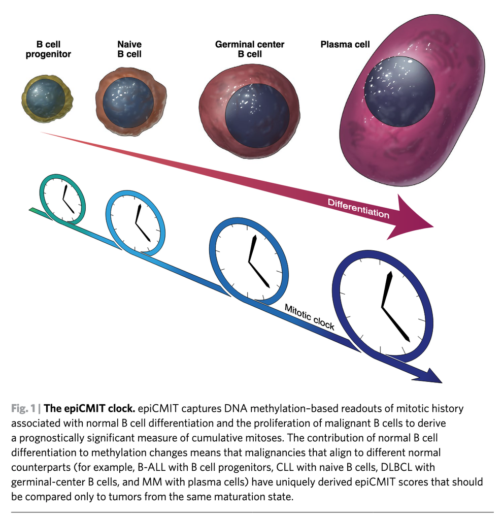

The epiCMIT mitotic clock, from Strati, P., Green, M.R. A, Nat Cancer, 2020.

# 2 Load required data.

## 2.1 Load R packages.

```r
## Load packages and set general options
options(stringsAsFactors = F,error=NULL)
##needed packages
library(GenomicRanges)
library(data.table)
```

## 2.2 Download and load required data into R.

We will download the data from github. Make sure you have internet connection.

```r
download.file("https://github.com/Duran-FerrerM/Pan-B-cell-methylome/raw/master/data/Estimate.epiCMIT.RData", destfile = "Estimate.epiCMIT.RData", method="libcurl")
load("Estimate.epiCMIT.RData")

## Take a look at RRBS data. Please, note that your data can be a matrix, data.frame or GRange object.
print(RRBS.SE.hg19.Examples$CW101)
```

[output not shown]

# 3 Analyses

The methodology to estimate the epiCMIT is the following:

1. Map your DNA methylation matrix to epiCMIT-CpGs and the correct genome assembly using the function `DNAm.to.epiCMIT`. This function converts a DNA methylation matrix (DNAm) into a suitable GRange object to calculate the epiCMIT and contains the following arguments:
- `DNAm`: DNA methylation matrix. Should be a matrix, data.frame or GRanges object.
- `DNAm.genome.assembly`: The genome assembly of the DNAm matrix. Supported versions are “hg19” and “hg38”.
- `map.DNAm.to`: Map the data to Illumina-450k epiCMIT-CpGs or WGBS epiCMIT-CpGs. Should be “Illumina.450K.epiCMIT” or “WGBS.epiCMIT”.
- `min.epiCMIT.CpGs`: Integer, default 800 CpGs. Recommended a minimum of 800 epiCMIT-CpGs, less CpGs have not been thoroughly tested.
- `CpGs.as.DNAm.rownames`: logical, default TRUE. Are rownames of your matrix CpG names? If so they will be used for mapping. If FALSE, coordinates should be provided. If `DNAm` is of class matrix and `CpGs.as.DNAm.rownames=FALSE`, CpG coordinates and DNAm info columns from DNAm should be provided in the following arguments:`DNAm.chr`, `DNAm.start`, `DNAm.end`, `DNAm.meth`
2. Calculate the epiCMIT after running `DNAm.to.epiCMIT` with the `epiCMIT`function, which contains the following arguments:
- `DNAm.epiCMIT`:The GRange object after running `DNAm.to.epiCMIT` function.
- `return.epiCMIT.annot`: logical indicating whether to export the epiCMIT-CpGs used and metadata info.
- `export.results`: logical, indicating whether to export the results.
- `export.results.dir`: character indicating the path to export the results.
- `export.results.name`: character string with the name for the exported file.

## 3.1 450k/EPIC Illumina array data.

The [original epiCMIT](https://www.nature.com/articles/s43018-020-00131-2) estimation is calculated from 450k and EPIC DNA methylation data.

```r
##
## Calculate epiCMIT in example Illumina 450K data from Duran-Ferrer 2020, Nature Cancer
##

head(Illumina.450k.hg19.example)
```

```
##                    S1       S1.1 Bcells.NBC Bcells.NBC.1 Bcells.GC.CB
## cg19715410 0.03281870 0.03204408  0.1315335    0.0700329    0.1107626
## cg18279094 0.02607567 0.02970688  0.1606909    0.1352674    0.2294113
## cg11823511 0.04829795 0.06345230  0.2384474    0.1095039    0.2925793
## cg24453699 0.08637016 0.06725103  0.2145321    0.1373994    0.4452114
## cg03989260 0.08927458 0.10001880  0.3149984    0.2808355    0.3639931
## cg14565725 0.08295045 0.10734008  0.1662055    0.1278814    0.2003273
##            Bcells.GC.CB.1 Bcells.ncsMBC Bcells.ncsMBC.1 Bcells.bmPC
## cg19715410      0.2497778     0.2458823       0.4375922   0.5352242
## cg18279094      0.4184098     0.4309570       0.5719976   0.6644706
## cg11823511      0.4131022     0.3857834       0.5039130   0.6403677
## cg24453699      0.4590231     0.3955716       0.4534276   0.6935022
## cg03989260      0.4303416     0.4102787       0.4789490   0.5853757
## cg14565725      0.3058882     0.3349291       0.3574508   0.5383428
##            Bcells.bmPC.1   ALL_637   ALL_111  MCL.M199  MCL.M195
## cg19715410     0.5361781 0.6234612 0.5251786 0.2117264 0.2466298
## cg18279094     0.7122690 0.6979892 0.7992767 0.8451157 0.9494396
## cg11823511     0.6835919 0.6410632 0.2016332 0.7028695 0.9289529
## cg24453699     0.6827635 0.3946649 0.7623484 0.8900264 0.9667127
## cg03989260     0.5905094 0.7772374 0.6203727 0.8037098 0.9220087
## cg14565725     0.5540709 0.5948486 0.9020117 0.5273358 0.4137479
##            DLBCL.DL30.D2611 DLBCL.DL33.D1450   CLL.131   CLL.519  MM_34475
## cg19715410        0.7191328        0.5545599 0.7516146 0.3368856 0.5450536
## cg18279094        0.8543303        0.5978679 0.8471168 0.8086633 0.8061107
## cg11823511        0.7264451        0.4858303 0.9281268 0.4706775 0.7506979
## cg24453699        0.8233838        0.4958754 0.9069049 0.4134561 0.8409076
## cg03989260        0.8014943        0.4929729 0.3928446 0.2600882 0.5510840
## cg14565725        0.7680909        0.5080088 0.2889624 0.2526042 0.2311253
##             MM_38267
## cg19715410 0.4488824
## cg18279094 0.7297705
## cg11823511 0.8005615
## cg24453699 0.9191897
## cg03989260 0.2505447
## cg14565725 0.7836650
```

```r
DNAm.epiCMIT <- DNAm.to.epiCMIT(DNAm = Illumina.450k.hg19.example,
                         DNAm.genome.assembly = "hg19",
                         map.DNAm.to = "Illumina.450K.epiCMIT",
                         min.epiCMIT.CpGs = 800 # minimum recommended
                         )
```

```
## Mapping the DNAm methylation matrix in hg19 genome assembly to 450K-based epiCMIT as reported in Duran-Ferrer.M 2020.
```

```r
DNAm.epiCMIT
```

```
## GRanges object with 1348 ranges and 20 metadata columns:
##              seqnames    ranges strand |        S1      S1.1 Bcells.NBC
##                 <Rle> <IRanges>  <Rle> | <numeric> <numeric>  <numeric>
##   cg19715410     chr1  29139021      * | 0.0328187 0.0320441   0.131534
##   cg18279094     chr1  63790044      * | 0.0260757 0.0297069   0.160691
##   cg11823511     chr1  91183697      * | 0.0482980 0.0634523   0.238447
##   cg24453699     chr1  91190891      * | 0.0863702 0.0672510   0.214532
##   cg03989260     chr1 119529360      * | 0.0892746 0.1000188   0.314998
##          ...      ...       ...    ... .       ...       ...        ...
##   cg04819337    chr21  44982367      * |  0.964340  0.941688   0.825908
##   cg05705496    chr21  45666671      * |  0.915620  0.919199   0.801698
##   cg07443748    chr22  17073594      * |  0.935098  0.895979   0.818871
##   cg02724647    chr22  17646207      * |  0.942553  0.933896   0.820176
##   cg09331835    chr22  21692413      * |  0.915718  0.927865   0.836925
##              Bcells.NBC.1 Bcells.GC.CB Bcells.GC.CB.1 Bcells.ncsMBC
##                 <numeric>    <numeric>      <numeric>     <numeric>
##   cg19715410    0.0700329     0.110763       0.249778      0.245882
##   cg18279094    0.1352674     0.229411       0.418410      0.430957
##   cg11823511    0.1095039     0.292579       0.413102      0.385783
##   cg24453699    0.1373994     0.445211       0.459023      0.395572
##   cg03989260    0.2808355     0.363993       0.430342      0.410279
##          ...          ...          ...            ...           ...
##   cg04819337     0.854883     0.644030       0.568468      0.548715
##   cg05705496     0.873003     0.544333       0.520256      0.631695
##   cg07443748     0.843503     0.623809       0.579205      0.543690
##   cg02724647     0.862859     0.741641       0.672352      0.639689
##   cg09331835     0.874563     0.815323       0.675565      0.646640
##              Bcells.ncsMBC.1 Bcells.bmPC Bcells.bmPC.1   ALL_637   ALL_111
##                    <numeric>   <numeric>     <numeric> <numeric> <numeric>
##   cg19715410        0.437592    0.535224      0.536178  0.623461  0.525179
##   cg18279094        0.571998    0.664471      0.712269  0.697989  0.799277
##   cg11823511        0.503913    0.640368      0.683592  0.641063  0.201633
##   cg24453699        0.453428    0.693502      0.682763  0.394665  0.762348
##   cg03989260        0.478949    0.585376      0.590509  0.777237  0.620373
##          ...             ...         ...           ...       ...       ...
##   cg04819337        0.520183    0.306169      0.332087  0.881284  0.933870
##   cg05705496        0.568901    0.340151      0.351566  0.483426  0.427183
##   cg07443748        0.504945    0.322319      0.342618  0.432292  0.179971
##   cg02724647        0.615848    0.436913      0.423863  0.913431  0.911068
##   cg09331835        0.637598    0.403076      0.382335  0.815445  0.723059
```

[output cut: 13 more lines]

```
##                CLL.519  MM_34475  MM_38267
##              <numeric> <numeric> <numeric>
##   cg19715410  0.336886  0.545054  0.448882
##   cg18279094  0.808663  0.806111  0.729771
##   cg11823511  0.470678  0.750698  0.800561
##   cg24453699  0.413456  0.840908  0.919190
##   cg03989260  0.260088  0.551084  0.250545
##          ...       ...       ...       ...
##   cg04819337  0.731931  0.273938  0.209698
##   cg05705496  0.663109  0.374354  0.299490
##   cg07443748  0.408895  0.305450  0.217465
##   cg02724647  0.858257  0.368123  0.226500
##   cg09331835  0.688484  0.300242  0.266912
##   -------
##   seqinfo: 22 sequences from an unspecified genome; no seqlengths
```

```r
##calculate epiCMIT
epiCMIT.Illumina <- epiCMIT(DNAm.epiCMIT = DNAm.epiCMIT,
                             return.epiCMIT.annot = FALSE,
                             export.results = TRUE,
                             export.results.dir = ".",
                             export.results.name = "Illumina.450k.example_"
                             )
```

```
## Calculating the epiCMIT mitotic clock with DNAm.to.epiCMIT() parameters:
## DNAm.class = data.frame
## DNAm.genome.assembly = hg19
## map.DNAm.to = Illumina.450K.epiCMIT
## CpGs.as.DNAm.rownames = TRUE
## DNAm.chr = NULL
## DNAm.start = NULL
## DNAm.end = NULL
## DNAm.meth = NULL
## min.epiCMIT.CpGs = 800
```

```r
head(epiCMIT.Illumina$epiCMIT.scores)
```

```
##                       Samples    epiCMIT epiCMIT.hyper epiCMIT.hypo
## S1                         S1 0.06727728    0.06428607   0.06727728
## S1.1                     S1.1 0.06690286    0.06087516   0.06690286
## Bcells.NBC         Bcells.NBC 0.18628517    0.18150005   0.18628517
## Bcells.NBC.1     Bcells.NBC.1 0.15363033    0.14141785   0.15363033
## Bcells.GC.CB     Bcells.GC.CB 0.33186043    0.22794942   0.33186043
## Bcells.GC.CB.1 Bcells.GC.CB.1 0.40810107    0.35610520   0.40810107
```

```r
epiCMIT.Illumina.results <- cbind(epiCMIT.Illumina$epiCMIT.scores,
                                  epiCMIT.CpGs=epiCMIT.Illumina$epiCMIT.run.info$epiCMIT.CpGs,
                                  epiCMIT.hyper.CpGs=epiCMIT.Illumina$epiCMIT.run.info$epiCMIT.hyper.CpGs,
                                  epiCMIT.hypo.CpGs=epiCMIT.Illumina$epiCMIT.run.info$epiCMIT.hypo.CpGs
                                  )

DT::datatable(epiCMIT.Illumina.results, options = list(scrollX = T, scrollY=T), rownames = F)
```

| Samples | epiCMIT | epiCMIT.hyper | epiCMIT.hypo | epiCMIT.CpGs | epiCMIT.hyper.CpGs | epiCMIT.hypo.CpGs |
| --- | --- | --- | --- | --- | --- | --- |
| S1 | 0.0672772788779171 | 0.0642860702728943 | 0.0672772788779171 | 1348 | 184 | 1164 |
| S1.1 | 0.0669028564222094 | 0.0608751636957107 | 0.0669028564222094 | 1348 | 184 | 1164 |
| Bcells.NBC | 0.18628516817036 | 0.181500045122239 | 0.18628516817036 | 1348 | 184 | 1164 |
| Bcells.NBC.1 | 0.153630326605711 | 0.141417847240859 | 0.153630326605711 | 1348 | 184 | 1164 |
| Bcells.GC.CB | 0.331860428418999 | 0.227949423530985 | 0.331860428418999 | 1348 | 184 | 1164 |
| Bcells.GC.CB.1 | 0.40810107473043 | 0.356105197293213 | 0.40810107473043 | 1348 | 184 | 1164 |
| Bcells.ncsMBC | 0.446733455803044 | 0.329347706807786 | 0.446733455803044 | 1348 | 184 | 1164 |
| Bcells.ncsMBC.1 | 0.482932392818598 | 0.41950787926711 | 0.482932392818598 | 1348 | 184 | 1164 |
| Bcells.bmPC | 0.681935070226648 | 0.591221565448196 | 0.681935070226648 | 1348 | 184 | 1164 |
| Bcells.bmPC.1 | 0.68736005027604 | 0.5993307820386 | 0.68736005027604 | 1348 | 184 | 1164 |

[output cut: 10 more lines]

```r
##export
fwrite(epiCMIT.Illumina.results,"epiCMIT.Illumina.arrays.scores.tsv",sep="\t")
```

## 3.2 RRBS/NGS data.

For NGS-based DNA methylaion data, a new strategy was developed in the [CLL-map study](https://www.nature.com/articles/s41588-022-01140-w). Briefly, an extended epiCMIT-CpG catalogue was found using Whole Genome Bisulphite data and is systematically searched in each sample separately, irrespective of CpG numbers and identity. All epiCMIT-CpG set behaves very similar and thus can be applied. You can check a more detailed tutorial [here](https://github.com/Duran-FerrerM/CLLmap-epigenetics).

To estimate the epiCMIT in all samples, we can then create a loop with the R function `lapply` and run both functions at the same time for all the samples to subsequently store all the results into a list. To do so, we can execute the following lines of code:

```r
##
## Example with RRBS-SE hg19 data
##

epiCMIT.RRBS <- suppressWarnings( ## supress warning so that all warning do not appear in the html document.
  suppressMessages(
    lapply(names(RRBS.SE.hg19.Examples),function(sample.i){

  ##transform data to run epiCMIT() function.
  DNAm.epiCMIT <- DNAm.to.epiCMIT(DNAm = RRBS.SE.hg19.Examples[[sample.i]],
                                  DNAm.genome.assembly = "hg19",
                                  map.DNAm.to = "WGBS.epiCMIT",
                                  min.epiCMIT.CpGs = 800 # minimum recommended
  )

  ##calculate epiCMIT
  epiCMIT.results <- epiCMIT(DNAm.epiCMIT = DNAm.epiCMIT,
                             return.epiCMIT.annot = TRUE,
                             export.results = FALSE, ## change to TRUE to export results for every single sample
                             export.results.dir = ".",
                             export.results.name = paste0("RRBS-SE.",sample.i,"_example_")
  )
})
)
)
```

We now can gather all the relevant results into a matrix-like structure so that we can export all the table at once.

```r
## prepare data to export it.
epiCMIT.RRBS.scores <- do.call(rbind,lapply(epiCMIT.RRBS,function(x){x[["epiCMIT.scores"]]}))
epiCMIT.RRBS.scores$epiCMIT.CpGs <- as.numeric(do.call(rbind,lapply(epiCMIT.RRBS,function(x){x[["epiCMIT.run.info"]][["epiCMIT.CpGs"]]})))
epiCMIT.RRBS.scores$epiCMIT.hyper.CpGs <- as.numeric(do.call(rbind,lapply(epiCMIT.RRBS,function(x){x[["epiCMIT.run.info"]][["epiCMIT.hyper.CpGs"]]})))
epiCMIT.RRBS.scores$epiCMIT.hypo.CpGs <- as.numeric(do.call(rbind,lapply(epiCMIT.RRBS,function(x){x[["epiCMIT.run.info"]][["epiCMIT.hypo.CpGs"]]})))
head(epiCMIT.RRBS.scores[,-1])
```

```
##             epiCMIT epiCMIT.hyper epiCMIT.hypo epiCMIT.CpGs epiCMIT.hyper.CpGs
## DFCI-5069 0.4691847     0.2696861    0.4691847         4826               1038
## DFCI-5071 0.5942540     0.5942540    0.4730709         3065                743
## DFCI-5102 0.5817348     0.4411374    0.5817348         5674               1236
## DFCI-5072 0.4945748     0.4693410    0.4945748         4362                955
## DFCI-5073 0.5578167     0.4235328    0.5578167         4258                958
## DFCI-5074 0.6760768     0.6065394    0.6760768         1096                241
##           epiCMIT.hypo.CpGs
## DFCI-5069              3788
## DFCI-5071              2322
## DFCI-5102              4438
## DFCI-5072              3407
## DFCI-5073              3300
## DFCI-5074               855
```

```r
DT::datatable(epiCMIT.RRBS.scores, options = list(scrollX = T, scrollY=T), rownames = F)
```

| Samples | epiCMIT | epiCMIT.hyper | epiCMIT.hypo | epiCMIT.CpGs | epiCMIT.hyper.CpGs | epiCMIT.hypo.CpGs |
| --- | --- | --- | --- | --- | --- | --- |
| DFCI-5069 | 0.469184741288279 | 0.26968612716763 | 0.469184741288279 | 4826 | 1038 | 3788 |
| DFCI-5071 | 0.59425397039031 | 0.59425397039031 | 0.473070887166236 | 3065 | 743 | 2322 |
| DFCI-5102 | 0.581734835511492 | 0.441137378640777 | 0.581734835511492 | 5674 | 1236 | 4438 |
| DFCI-5072 | 0.494574816554153 | 0.469341047120419 | 0.494574816554153 | 4362 | 955 | 3407 |
| DFCI-5073 | 0.557816696969697 | 0.423532776617954 | 0.557816696969697 | 4258 | 958 | 3300 |
| DFCI-5074 | 0.676076842105263 | 0.606539419087137 | 0.676076842105263 | 1096 | 241 | 855 |
| DFCI-5075 | 0.570595199778024 | 0.500041541353383 | 0.570595199778024 | 4668 | 1064 | 3604 |
| DFCI-5010 | 0.580447929936306 | 0.580447929936306 | 0.385902850435949 | 5729 | 1256 | 4473 |
| DFCI-5108 | 0.621069422423556 | 0.621069422423556 | 0.572825351672398 | 4082 | 883 | 3199 |
| DFCI-5109 | 0.441033636363636 | 0.441033636363636 | 0.424967189476347 | 5053 | 1100 | 3953 |

```r
##export
fwrite(epiCMIT.RRBS.scores,"epiCMIT.RRBS.scores.tsv",sep="\t")
```

## 3.3 Get all code at once

```r
knitr::opts_chunk$set(echo = TRUE)

## Load packages and set general options
options(stringsAsFactors = F,error=NULL)
##needed packages
library(GenomicRanges)
library(data.table)


download.file("https://github.com/Duran-FerrerM/Pan-B-cell-methylome/raw/master/data/Estimate.epiCMIT.RData", destfile = "Estimate.epiCMIT.RData", method="libcurl")
load("Estimate.epiCMIT.RData")

## Take a look at RRBS data. Please, note that your data can be a matrix, data.frame or GRange object.
print(RRBS.SE.hg19.Examples$CW101)


##
## Calculate epiCMIT in example Illumina 450K data from Duran-Ferrer 2020, Nature Cancer
##

head(Illumina.450k.hg19.example)
DNAm.epiCMIT <- DNAm.to.epiCMIT(DNAm = Illumina.450k.hg19.example,
                         DNAm.genome.assembly = "hg19",
                         map.DNAm.to = "Illumina.450K.epiCMIT",
                         min.epiCMIT.CpGs = 800 # minimum recommended
                         )
DNAm.epiCMIT

##calculate epiCMIT
epiCMIT.Illumina <- epiCMIT(DNAm.epiCMIT = DNAm.epiCMIT,
                             return.epiCMIT.annot = FALSE,
                             export.results = TRUE,
                             export.results.dir = ".",
                             export.results.name = "Illumina.450k.example_"
                             )
head(epiCMIT.Illumina$epiCMIT.scores)
epiCMIT.Illumina.results <- cbind(epiCMIT.Illumina$epiCMIT.scores,
                                  epiCMIT.CpGs=epiCMIT.Illumina$epiCMIT.run.info$epiCMIT.CpGs,
                                  epiCMIT.hyper.CpGs=epiCMIT.Illumina$epiCMIT.run.info$epiCMIT.hyper.CpGs,
                                  epiCMIT.hypo.CpGs=epiCMIT.Illumina$epiCMIT.run.info$epiCMIT.hypo.CpGs
                                  )

DT::datatable(epiCMIT.Illumina.results, options = list(scrollX = T, scrollY=T), rownames = F)

##export
fwrite(epiCMIT.Illumina.results,"epiCMIT.Illumina.arrays.scores.tsv",sep="\t")


##
## Example with RRBS-SE hg19 data
##

epiCMIT.RRBS <- suppressWarnings( ## supress warning so that all warning do not appear in the html document.
  suppressMessages(
    lapply(names(RRBS.SE.hg19.Examples),function(sample.i){

  ##transform data to run epiCMIT() function.
  DNAm.epiCMIT <- DNAm.to.epiCMIT(DNAm = RRBS.SE.hg19.Examples[[sample.i]],
                                  DNAm.genome.assembly = "hg19",
                                  map.DNAm.to = "WGBS.epiCMIT",
                                  min.epiCMIT.CpGs = 800 # minimum recommended
  )

  ##calculate epiCMIT
  epiCMIT.results <- epiCMIT(DNAm.epiCMIT = DNAm.epiCMIT,
                             return.epiCMIT.annot = TRUE,
                             export.results = FALSE, ## change to TRUE to export results for every single sample
                             export.results.dir = ".",
                             export.results.name = paste0("RRBS-SE.",sample.i,"_example_")
  )
})
)
)



## prepare data to export it.
epiCMIT.RRBS.scores <- do.call(rbind,lapply(epiCMIT.RRBS,function(x){x[["epiCMIT.scores"]]}))
epiCMIT.RRBS.scores$epiCMIT.CpGs <- as.numeric(do.call(rbind,lapply(epiCMIT.RRBS,function(x){x[["epiCMIT.run.info"]][["epiCMIT.CpGs"]]})))
epiCMIT.RRBS.scores$epiCMIT.hyper.CpGs <- as.numeric(do.call(rbind,lapply(epiCMIT.RRBS,function(x){x[["epiCMIT.run.info"]][["epiCMIT.hyper.CpGs"]]})))
epiCMIT.RRBS.scores$epiCMIT.hypo.CpGs <- as.numeric(do.call(rbind,lapply(epiCMIT.RRBS,function(x){x[["epiCMIT.run.info"]][["epiCMIT.hypo.CpGs"]]})))
head(epiCMIT.RRBS.scores[,-1])

DT::datatable(epiCMIT.RRBS.scores, options = list(scrollX = T, scrollY=T), rownames = F)


##export
fwrite(epiCMIT.RRBS.scores,"epiCMIT.RRBS.scores.tsv",sep="\t")
```